# Capstone Project Analyzing League of Legends Dataset

Created by Shannon Song

```python
#!pip install matplotlib
#!pip install xgboost

import pandas as pd
import numpy as np
import matplotlib.pyplot as plt
from sklearn.datasets import make_classification
from sklearn.ensemble import ExtraTreesClassifier
import seaborn as sns
from xgboost import XGBClassifier
from sklearn.model_selection import train_test_split
from sklearn.preprocessing import StandardScaler
from sklearn.metrics import classification_report, confusion_matrix
from sklearn import metrics
from sklearn.tree import DecisionTreeClassifier
from sklearn.model_selection import RandomizedSearchCV


import warnings
warnings.filterwarnings('ignore')
pd.options.display.float_format = '{:,.2f}'.format
pd.set_option('display.max_rows', 100)
pd.set_option('display.max_columns', 200)
```

The dataset selected comes from Kaggle and is called 'LeagueofLegends.csv'. There are multiple datasets available and a lot of information provided. To narrow down the scope of this project, I have focused on only champion selections and the outcome of the game. This dataset contains 7,620 unique records from competitive matches between 2015 and 2017 from NALCS, EULCS, LCK, LMS, and CBLoL leagues. This dataset also includes matches from the World Championship and the Mid-Season Invititationals. This is important to keep in mind because we will be analyzes data from high ELO players - or those who are at a high level of competition and think differently than most other players. As such, this analysis could be helpful for same ELO players but might not be helpful for lower ELO players who might act differently in game.

```python
# Two ways you can import from local database.

# First method, upload csv.

data = pd.read_csv('LeagueofLegends.csv')

# Second method, download directly from kaggle using the kaggle api. I did not do this method,
# but here is generally the code you would follow.
#!pip install kaggle
#import kaggle

#url = 'https://www.kaggle.com/chuckephron/leagueoflegends/LeagueofLegends.csv'

#kaggle.api.authenticate()
#kaggle.api.dataset_download_files('LeagueofLegends.csv', path = url)
```

Once the data is imported, the next step is to get an idea of what data we are working with. Specifically for this project, I am curious if we can solely use champion selections to predict the outcome of a game.

I first printed out column names and then added my columns of interest to my dataset.

```python
# Printing column names and to pull interesting columns into dataframe and looking at the head.

data.head()
for col in data.columns:
    print(col)

df = data[['bResult','rResult','blueTopChamp','blueJungleChamp','blueMiddleChamp','blueADCChamp','blueSupportChamp','redTopChamp','redJungleChamp',
         'redMiddleChamp','redADCChamp','redSupportChamp']].copy()
data.head()
```

```
League
Year
Season
Type
blueTeamTag
bResult
rResult
redTeamTag
gamelength
golddiff
goldblue
bKills
bTowers
bInhibs
bDragons
bBarons
bHeralds
goldred
rKills
rTowers
rInhibs
rDragons
rBarons
rHeralds
blueTop
blueTopChamp
goldblueTop
blueJungle
blueJungleChamp
goldblueJungle
blueMiddle
blueMiddleChamp
goldblueMiddle
blueADC
blueADCChamp
goldblueADC
blueSupport
blueSupportChamp
goldblueSupport
blueBans
redTop
redTopChamp
goldredTop
redJungle
redJungleChamp
goldredJungle
redMiddle
redMiddleChamp
goldredMiddle
redADC
redADCChamp
goldredADC
redSupport
redSupportChamp
goldredSupport
redBans
Address
```

|  | League | Year | Season | Type | blueTeamTag | bResult | rResult | redTeamTag | gamelength | golddiff | goldblue | bKills | bTowers | bInhibs | bDragons | bBarons | bHeralds | goldred | rKills | rTowers | rInhibs | rDragons | rBarons | rHeralds | blueTop | blueTopChamp | goldblueTop | blueJungle | blueJungleChamp | … |
| --- | --- | --- | --- | --- | --- | --- | --- | --- | --- | --- | --- | --- | --- | --- | --- | --- | --- | --- | --- | --- | --- | --- | --- | --- | --- | --- | --- | --- | --- | --- |
| 0 | NALCS | 2015 | Spring | Season | TSM | 1 | 0 | C9 | 40 | [0, 0, -14, -65, -268, -431, -488, -789, -494,... | [2415, 2415, 2711, 3887, 5068, 6171, 7412, 866... | [[10.82, 'C9 Hai', 'TSM Bjergsen', [], 9229, 8... | [[27.542, 'MID_LANE', 'BASE_TURRET'], [39.269,... | [[36.686, 'MID_LANE'], [29.274, 'MID_LANE']] | [[37.267, None]] | [] | [] | [2415, 2415, 2725, 3952, 5336, 6602, 7900, 945... | [[16.529, 'TSM Lustboy', 'C9 Balls', ['C9 Mete... | [[39.23, 'TOP_LANE', 'INNER_TURRET'], [20.681,... | [] | [[17.14, None], [30.934, None], [24.641, None]] | [[29.954]] | [] | Dyrus | Irelia | [475, 475, 532, 687, 893, 1058, 1172, 1471, 18... | Santorin | RekSai | … |
| 1 | NALCS | 2015 | Spring | Season | CST | 0 | 1 | DIG | 38 | [0, 0, -26, -18, 147, 237, -152, 18, 88, -242,... | [2415, 2415, 2705, 4108, 5511, 6797, 7637, 895... | [[11.104, 'DIG Shiphtur', 'CST Jesiz', ['CST I... | [[23.239, 'BOT_LANE', 'OUTER_TURRET'], [33.018... | [] | [[32.545, None], [26.177, None], [19.119, None]] | [[29.255]] | [] | [2415, 2415, 2731, 4126, 5364, 6560, 7789, 893... | [[12.387, 'CST Jesiz', 'DIG Gamsu', ['DIG Ship... | [[19.257, 'MID_LANE', 'OUTER_TURRET'], [15.206... | [[36.813, 'MID_LANE']] | [[12.264, None]] | [] | [] | Cris | Gnar | [475, 475, 532, 791, 1127, 1509, 1674, 1875, 2... | Impaler | Rengar | … |
| 2 | NALCS | 2015 | Spring | Season | WFX | 1 | 0 | GV | 40 | [0, 0, 10, -60, 34, 37, 589, 1064, 1258, 913, ... | [2415, 2415, 2726, 3794, 4933, 6236, 8109, 965... | [[5.255, 'GV Keane', 'WFX Pobelter', ['WFX Sho... | [[15.045, 'BOT_LANE', 'OUTER_TURRET'], [39.566... | [[37.511, 'TOP_LANE'], [37.38, 'BOT_LANE'], [3... | [[24.577, None], [37.867, None], [30.87, None]... | [[35.144]] | [] | [2415, 2415, 2716, 3854, 4899, 6199, 7520, 859... | [[8.449, 'WFX Altec', 'GV Cop', ['GV BunnyFuFu... | [[24.62, 'MID_LANE', 'OUTER_TURRET'], [30.493,... | [] | [] | [] | [] | Flaresz | Renekton | [475, 475, 533, 673, 828, 1075, 1428, 1775, 21... | ShorterACE | Rengar | … |
| 3 | NALCS | 2015 | Spring | Season | TIP | 0 | 1 | TL | 41 | [0, 0, -15, 25, 228, -6, -243, 175, -346, 16, ... | [2415, 2415, 2705, 3847, 5398, 6473, 7720, 930... | [[8.274, 'TL Quas', 'TIP Rhux', ['TIP Apollo']... | [[19.941, 'BOT_LANE', 'OUTER_TURRET'], [38.77,... | [] | [] | [[37.513]] | [] | [2415, 2415, 2720, 3822, 5170, 6479, 7963, 913... | [[7.768, 'TIP Rush', 'TL IWDominate', ['TL Fen... | [[36.384, 'MID_LANE', 'NEXUS_TURRET'], [31.665... | [[35.867, 'MID_LANE']] | [[26.274, None], [10.153, None], [18.515, None... | [] | [] | Rhux | Irelia | [475, 475, 532, 646, 992, 1253, 1408, 1752, 21... | Rush | JarvanIV | … |
| 4 | NALCS | 2015 | Spring | Season | CLG | 1 | 0 | T8 | 35 | [40, 40, 44, -36, 113, 158, -121, -191, 23, 20... | [2415, 2415, 2710, 3950, 5404, 6666, 7887, 913... | [[11.438, 'T8 Dodo8', 'CLG Doublelift', ['CLG ... | [[22.594, 'MID_LANE', 'OUTER_TURRET'], [34.213... | [[34.069, 'BOT_LANE']] | [[14.589, None], [30.307, None]] | [[32.556]] | [] | [2375, 2375, 2666, 3986, 5291, 6508, 8008, 932... | [[11.988, 'CLG Doublelift', 'T8 Porpoise8', ['... | [[11.644, 'MID_LANE', 'OUTER_TURRET'], [12.438... | [] | [[21.901, None]] | [] | [] | Benny | Gnar | [475, 475, 532, 733, 1038, 1258, 1546, 1850, 2... | Xmithie | JarvanIV | … |

The next step is to convert all my champion selection data into numerical form. This will make it easier for any computer programs to read and use. The way I went about doing this was factorizing the champions and then saving the factors in a list, adding them back into the dataset with one game result - blue wins. Having Blue and Red wins are redundant and not necessary. However, it is important to note that we will now be analyzing wins from the perspective of the blue team.

Once this is done, we will also be looking at generic distributions of each column and to also check if the target - 'wins' - is heavily skewed. Heavy skew can make our algorithms really good at predicting for the direction of the skew and not great at handling anything else.

Given the nature of the game, we expect some skewing in the champion selection because not all champions are fit for all roles.

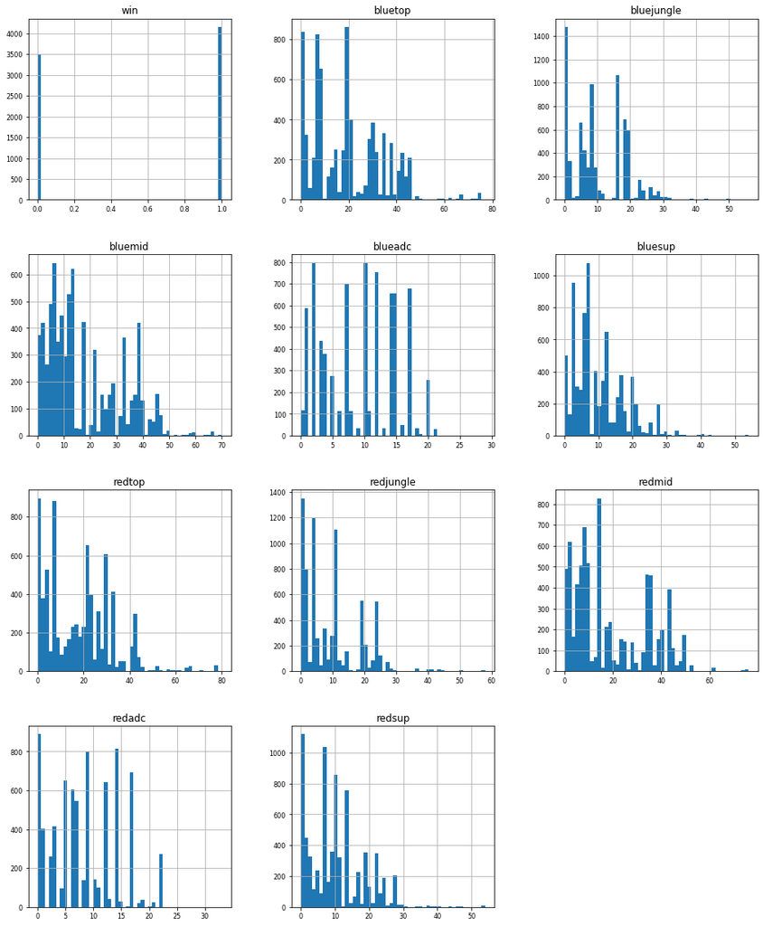

```python
# Convert data to numeric
df.head()
bluetop,btun = pd.factorize(df['blueTopChamp'])
bluejungle,bjun = pd.factorize(df['blueJungleChamp'])
bluemid,bmun = pd.factorize(df['blueMiddleChamp'])
blueadc,baun = pd.factorize(df['blueADCChamp'])
bluesup,bsun = pd.factorize(df['blueSupportChamp'])
redtop,rtun = pd.factorize(df['redTopChamp'])
redjungle,rjun = pd.factorize(df['redJungleChamp'])
redmid,rmun = pd.factorize(df['redMiddleChamp'])
redadc,raun = pd.factorize(df['redADCChamp'])
redsup,rsun = pd.factorize(df['redSupportChamp'])
list1 = [bluetop,bluejungle,bluemid,blueadc,bluesup,redtop,redjungle,redsup,redadc,redmid]

bluetop = bluetop.tolist()
bluejungle = bluejungle.tolist()
bluemid = bluemid.tolist()
blueadc = blueadc.tolist()
bluesup = bluesup.tolist()
redtop = redtop.tolist()
redjungle = redjungle.tolist()
redmid = redmid.tolist()
redadc = redadc.tolist()
redsup = redsup.tolist()

lol_df = pd.DataFrame(np.column_stack([df['bResult'],data['gamelength'],bluetop,bluejungle,bluemid,blueadc,bluesup,redtop,redjungle,
                     redmid,redadc,redsup]), columns = ['win','gamelength','bluetop','bluejungle','bluemid',
                     'blueadc','bluesup','redtop','redjungle','redmid','redadc','redsup'])

lol_df
selected_column = lol_df[['win','bluetop','bluejungle','bluemid',
                     'blueadc','bluesup','redtop','redjungle','redmid','redadc','redsup']]

selected_column.hist(figsize=(16, 20), bins=50, xlabelsize=8, ylabelsize=8)

plt.show()
```

The next step is to take a look at how correlated the features are to the target. We will use both the feature importances from ExtraTreesClassifier model as well as a correlation heatmap matrix.

```
[0.10000449 0.09275465 0.08601512 0.09426532 0.08842583 0.09071492
 0.09307006 0.08699354 0.09478757 0.08374238 0.08922613]
```

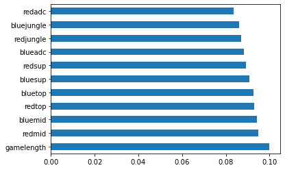

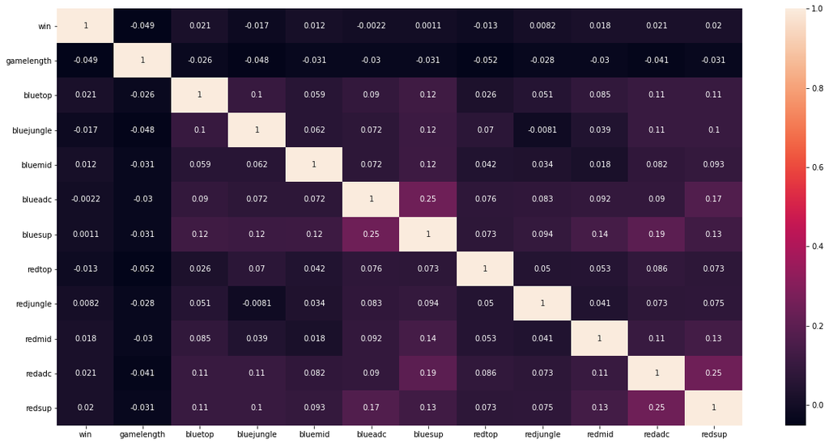

```python
lol_df.corr()
features = lol_df.iloc[:, lol_df.columns != 'win']
target = lol_df.iloc[:, lol_df.columns == 'win']
forest = ExtraTreesClassifier(n_estimators = 250, random_state = 0)

forest.fit(features,target)


print(forest.feature_importances_)


feat_importances = pd.Series(forest.feature_importances_, index=features.columns)
feat_importances.nlargest(20).plot(kind='barh')
plt.show()

lol_df.corr()
plt.figure(figsize=(20,10))
sns.heatmap(lol_df.corr(), annot=True)
plt.show()
```

```python
X_train, X_test, y_train, y_test = train_test_split(features, target, test_size = 0.4, random_state = 0)
print(X_train.shape)
print(X_test.shape)
print(y_train.shape)
print(y_test.shape)
```

```
(4572, 11)
(3048, 11)
(4572, 1)
(3048, 1)
```

The model we will use today is XGBClassifier, with reasonable defaults set. I have converted the predictions from probability to binary to match the format of the test set. The AUC of the ROC is not great for this model. The dotted blue line represents a performance no better than randomly guessing. Our model does slightly better than randomly guessing, but not by much.

```
[19:57:04] WARNING: C:/Users/Administrator/workspace/xgboost-win64_release_1.3.0/src/learner.cc:1061: Starting in XGBoost 1.3.0, the default evaluation metric used with the objective 'binary:logistic' was changed from 'error' to 'logloss'. Explicitly set eval_metric if you'd like to restore the old …
Model accuracy in the training sample is : 68.04 %
Model accuracy in test sample is:  53.25 %
[0.3744598  0.5761804  0.49302626 ... 0.5387047  0.55141884 0.7131693 ]
[0 1 0 ... 1 1 1]
```

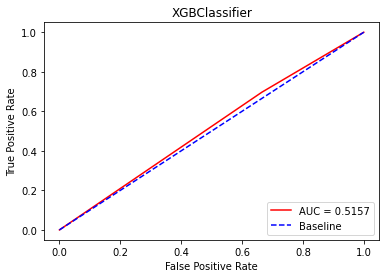

```
              precision    recall  f1-score   support

           0       0.48      0.33      0.39      1383
           1       0.56      0.70      0.62      1665

    accuracy                           0.53      3048
   macro avg       0.52      0.52      0.51      3048
weighted avg       0.52      0.53      0.52      3048
```

```python
model_XGB = XGBClassifier(learning_rate = 0.01,
                         n_estimators = 1000,
                         max_depth = 3,
                         subsample = 0.8,
                         colsample_bytree = 1,
                          gamma = 1)
model_XGB.fit(X_train, y_train)
acc_XGB= round(model_XGB.score(X_train,y_train)*100,2)
print("Model accuracy in the training sample is :",acc_XGB,"%")

acc_XGB_test = round(model_XGB.score(X_test, y_test) * 100, 2)
print("Model accuracy in test sample is: ", acc_XGB_test, "%")

y_pred_probx = model_XGB.predict_proba(X_test)[:,1]

print(y_pred_probx)
model_binary = np.vectorize(lambda i: int(i>= 0.5))(y_pred_probx)

print(model_binary)


fpr, tpr, t = metrics.roc_curve(y_test, model_binary)
auc = metrics.roc_auc_score(y_test, model_binary)
plt.plot(fpr,tpr, color = 'red', label = 'AUC = ' + str(round(auc,4)))
plt.plot([0,1], [0,1], color = 'blue', linestyle = '--', label = 'Baseline')
plt.xlabel('False Positive Rate')
plt.ylabel('True Positive Rate')
plt.title('XGBClassifier')
plt.legend(loc = 'lower right')
plt.figure(figsize = (100,90))
plt.show()
print(classification_report(y_test,model_binary))
```

Next we will try to hypertune the model to increase performance. For this, we could use random search or grid search. In this case, I selected random search.

```python
params = {
    'min_child_weight': [1,2,3,4,5,6,7,8,9,10],
    'gamma': [0.5,1,1.5,2,5],
    'max_depth': [1,2,3,4,5,6,7,8,9,10,15,20],
    'subsample': [0.5,0.6,0.7,0.8,0.9,1],
    'colsample_bytree': [0.5,0.6,0.7,0.8,0.9,1]
}
folds = 5
n_iterations = 100

random_search = RandomizedSearchCV(model_XGB, param_distributions = params, n_iter = n_iterations,
                                  scoring = 'roc_auc', random_state = 1)
random_search.fit(X_train, y_train)
```

[output not shown]

[output cut: 484 more lines]

```
RandomizedSearchCV(estimator=XGBClassifier(base_score=0.5, booster='gbtree',
                                           colsample_bylevel=1,
                                           colsample_bynode=1,
                                           colsample_bytree=1, gamma=1,
                                           gpu_id=-1, importance_type='gain',
                                           interaction_constraints='',
                                           learning_rate=0.01, max_delta_step=0,
                                           max_depth=3, min_child_weight=1,
                                           missing=nan,
                                           monotone_constraints='()',
                                           n_estimators=1000, n_jobs=12,
                                           num_parallel_tre...
                                           reg_alpha=0, reg_lambda=1,
                                           scale_pos_weight=1, subsample=0.8,
                                           tree_method='exact',
                                           validate_parameters=1,
                                           verbosity=None),
                   n_iter=100,
                   param_distributions={'colsample_bytree': [0.5, 0.6, 0.7, 0.8,
                                                             0.9, 1],
                                        'gamma': [0.5, 1, 1.5, 2, 5],
                                        'max_depth': [1, 2, 3, 4, 5, 6, 7, 8, 9,
                                                      10, 15, 20],
                                        'min_child_weight': [1, 2, 3, 4, 5, 6,
                                                             7, 8, 9, 10],
                                        'subsample': [0.5, 0.6, 0.7, 0.8, 0.9,
                                                      1]},
                   random_state=1, scoring='roc_auc')
```

```
{'subsample': 0.8, 'min_child_weight': 7, 'max_depth': 20, 'gamma': 1.5, 'colsample_bytree': 0.9}
[20:26:53] WARNING: C:/Users/Administrator/workspace/xgboost-win64_release_1.3.0/src/learner.cc:541:
Parameters: { param } might not be used.

  This may not be accurate due to some parameters are only used in language bindings but
  passed down to XGBoost core.  Or some parameters are not used but slip through this
  verification. Please open an issue if you find above cases.


[20:26:53] WARNING: C:/Users/Administrator/workspace/xgboost-win64_release_1.3.0/src/learner.cc:1061: Starting in XGBoost 1.3.0, the default evaluation metric used with the objective 'binary:logistic' was changed from 'error' to 'logloss'. Explicitly set eval_metric if you'd like to restore the old …
Model accuracy in the training sample is : 97.68 %
Model accuracy in test sample is:  52.13 %
[0.10780008 0.65641016 0.54578805 ... 0.74677765 0.3389324  0.7793485 ]
[0 1 1 ... 1 0 1]
```

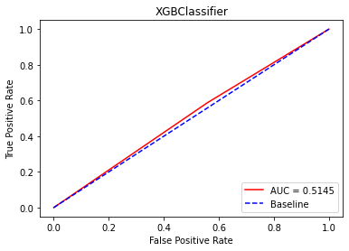

```
              precision    recall  f1-score   support

           0       0.47      0.44      0.46      1383
           1       0.56      0.59      0.57      1665

    accuracy                           0.52      3048
   macro avg       0.51      0.51      0.51      3048
weighted avg       0.52      0.52      0.52      3048
```

```python
print(random_search.best_params_)

model_XGB = XGBClassifier(param = random_search.best_params_)
model_XGB.fit(X_train, y_train)
acc_XGB= round(model_XGB.score(X_train,y_train)*100,2)
print("Model accuracy in the training sample is :",acc_XGB,"%")

acc_XGB_test = round(model_XGB.score(X_test, y_test) * 100, 2)
print("Model accuracy in test sample is: ", acc_XGB_test, "%")

y_pred_probx = model_XGB.predict_proba(X_test)[:,1]

print(y_pred_probx)
model_binary = np.vectorize(lambda i: int(i>= 0.5))(y_pred_probx)

print(model_binary)


fpr, tpr, t = metrics.roc_curve(y_test, model_binary)
auc = metrics.roc_auc_score(y_test, model_binary)
plt.plot(fpr,tpr, color = 'red', label = 'AUC = ' + str(round(auc,4)))
plt.plot([0,1], [0,1], color = 'blue', linestyle = '--', label = 'Baseline')
plt.xlabel('False Positive Rate')
plt.ylabel('True Positive Rate')
plt.title('XGBClassifier')
plt.legend(loc = 'lower right')
plt.figure(figsize = (100,90))
plt.show()
print(classification_report(y_test,model_binary))
```